# Reading data and intro to plotting

Laura Melissa Guzman and Juan Zuloaga

## Making your own csv file

A csv, stands for comma separated values, is a type of file which can be easily read by R. Most likely, the data you have collected will be in an Exel format. You can make csv’s from your Excel files.

## Reading in data

Before loading this datset, which is in csv format, click on the data called “australian_vertebrates.csv” and then click on *View File*. This will allow you to see how the file is structured. On the first row you will see the column names and you will see that the values between each column is separated by a comma.

Now we are ready to read in the data.

Note, data origin http://esapubs.org/archive/ecol/E091/181/default.htm#data https://ecologicaldata.org

Juan, should we translate the df to spanish?

```r
australian_verts <- read.csv("australian_vertebrates.csv")

head(australian_verts)
```

```
##   TAXA                      SPECIES        Common_name mass color_dimorphism
## 1 BIRD          Acanthiza katherina Mountain Thornbill  8.9                0
## 2 BIRD Acanthorhynchus tenuirostris  Eastern Spinebill   11                1
## 3 BIRD    Accipiter novaehollandiae       Grey Goshawk  515                0
## 4 BIRD         Ailuroedus melanotis    Spotted Catbird  166                0
## 5 BIRD                Alcedo azurea   Azure Kingfisher 33.8                0
## 6 BIRD               Alcedo pusilla  Little Kingfisher 14.5                0
##   max_lifespan endemic
## 1           15       1
## 2           16       0
## 3           20       0
## 4           20       0
## 5           21       0
## 6           21       0
```

## Data frames

The dataset you just loaded is a data frame. A data frame consists of multiple columns and rows. In a data frame, each column has to be the same ‘type’, but not all the columns need to be the same.

# Do we have more birds or reptiles in our dataset?

## Packages

In order to answer this question we can plot our data using bar graphs. In a bar graph we have different categories on the x-axis, and the count for each category.

A package that is very practical and produces beautiful plots is `ggplot2`. As you recall, a package is a set of functions that are ‘packaged’ together. First you will to instal this package, you only need to install the package once. You can use the following function:

```r
install.packages('ggplot2')
```

Once you have installed it, you will need to ‘load it’. Loading it makes the functions available for you to use. You will need to load it every time you want to use the functions.

```r
library(ggplot2)
```

## Bar plots

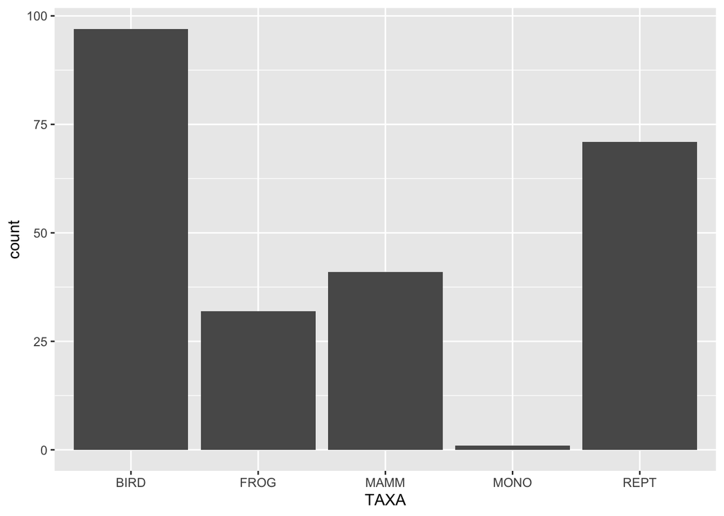

```r
ggplot(data = australian_verts) + geom_bar(aes(x = TAXA))
```